# Ngiam and Lee (2026) - memoryReproduction

William XQ Ngiam

2025-12-11

## Overview

This file is associated with the preprint titled [“Similarity judgments and visual working memory do not share the same cognitive representation”](https://osf.io/preprints/psyarxiv/fm9vz_v1) by William XQ Ngiam (Adelaide University) and Michael D Lee (University of California Irvine). This research project models the cognitive representation underlying perceptual tasks, working memory tasks, and similarity judgment tasks.

The following model recovers the underlying psychological space for the orientation **memory reproduction** task in [Tomic and Bays (2024)](https://psycnet.apa.org/doi/10.1037/xlm0001172). In this task, either three or six oriented lines (randomly sampled from 0 to 180 degrees) is shown to the subject. The subject is probed to recall the orientation of one of the shown lines, and has to reproduce the orientation as closely as possible.

The following code builds a Bayesian Thurstonian model using JAGS, recovering the latent representation of the orientations. This memory model **includes swap errors** - that the subject may erroneously reproduce the orientation of a non-target item in the array. A memory model that does not include swap errors is included in the original manuscript; this code can be easily adjusted to run that model.

### Requirements

The following files should be saved in your working directory:

- The data file (“oriWMData_clean.csv”) - [downloadable here](https://github.com/WilliamNgiam/orientationModeling/blob/main/data/oriWMData_clean.csv).
- The model text file (“memoryReproduction_jags.txt”) - [downloadable here](https://github.com/WilliamNgiam/orientationModeling/blob/main/memoryReproduction/memoryReproduction_jags.txt).

You will also need to have installed JAGS on your device. The installer can be accessed here: [https://sourceforge.net/projects/mcmc-jags/files/]. The following code was built using JAGS 4.3.2.

### Setup

```r
# Load required packages
library(R2jags) # v0.8-9
library(tidyverse) # v2.0.0
library(coda) # v0.19-4.1
library(ggmcmc) # v1.5.1.2

# Provide R session output
```

```r
# Set RNG seed for reproducibility
set.seed(42)

# Remove hashes from output
knitr::opts_chunk$set(comment = NA)
```

### Load data

```r
# Load in Tomic and Bays (2024) dataset
memData <- read_csv(paste0(getwd(),"/oriWMData_clean.csv"))

# Create intervals to match the Tomic and Bays (2024) perceptual task.
binIntervals = seq(-pi,pi,length.out = 73)

# Assign indices to the closest interval for the target (stimulus) values and response values
memData <- memData %>%
  mutate(response = signif(response,digits = 5)) %>%
  rowwise() %>%
  # Change all NaNs to NA
  mutate(across(c("nontarget_3", "nontarget_4", "nontarget_5"),
                na_if, NaN)) %>%
  # Match response and target values to the intervals on the semi-circle
  mutate(responseIndex = which.min(abs(response-binIntervals)),
         targetIndex = which.min(abs(target-binIntervals)),
         nontarget1_idx = which.min(abs(nontarget_1-binIntervals)),
         nontarget2_idx = which.min(abs(nontarget_2-binIntervals)),
         nontarget3_idx = list(case_when(!is.na(nontarget_3) ~ which.min(abs(as.numeric(nontarget_3)-binIntervals)))),
         nontarget4_idx = list(case_when(!is.na(nontarget_4) ~ which.min(abs(as.numeric(nontarget_4)-binIntervals)))),
         nontarget5_idx = list(case_when(!is.na(nontarget_5) ~ which.min(abs(as.numeric(nontarget_5)-binIntervals))))) %>%
  # The response and target values closest to pi are re-indexed to the first bin (0)
  mutate(responseIndex = case_when(responseIndex == 73 ~ 1,
                                   .default = responseIndex),
         targetIndex = case_when(targetIndex == 73 ~ 1,
                                 .default = targetIndex)) %>%
  # Change values
  mutate(target = (target+pi)/2,
         response = (response + pi)/2)

# Set up the true values to be recovered
muTruth = (binIntervals[-73] + pi)/2 # Remove the last index because that is the point at which the circle wraps around
sigmaTruth = 0.01

# Assign data to vectors
setSize <- as.vector(memData$setsize/3)
stim <- memData %>%
  select(targetIndex, nontarget1_idx, nontarget2_idx, nontarget3_idx, nontarget4_idx, nontarget5_idx)
stim <- as.matrix(stim)
y <- as.numeric(memData$response)
nTrials <- as.numeric(length(memData$response))
nStimuli <- as.numeric(length(muTruth))
```

### Read in data for JAGS

```r
data.jags <- list("setSize","stim","y","nTrials","nStimuli")
bayes.mod.params <- c("mu","sigma", "omega3", "omega6")
bayes.mod.inits <- function() {
  list("sigma" = runif(2)*pi)
}
```

### Run model fit

```r
bayes.mod.fit <- jags(data = data.jags,
                      inits = bayes.mod.inits,
                      parameters.to.save = bayes.mod.params,
                      n.chains = 4,
                      n.iter = 8000,
                      n.burnin = 1000,
                      model.file = paste0(getwd(),"/memoryReproduction_jags.txt"))
```

```
module glm loaded
```

```
Compiling data graph
   Initializing
   Reading data back into data table
```

### Evaluate model

```r
print(bayes.mod.fit)
```

```
Inference for Bugs model at "/Users/will.ngiam/Documents/1 RESEARCH/10 Projects/10.05 Generated MDS/simiJAGS/memoryReproduction_jags.txt", fit using jags,
 4 chains, each with 8000 iterations (first 1000 discarded), n.thin = 7
 n.sims = 4000 iterations saved. Running time = 1309.164 secs
           mu.vect sd.vect     2.5%      25%      50%      75%    97.5%  Rhat
mu[1]        0.000   0.000    0.000    0.000    0.000    0.000    0.000 1.000
mu[2]        0.277   0.054    0.169    0.242    0.278    0.312    0.383 1.001
mu[3]        0.340   0.046    0.250    0.310    0.340    0.371    0.427 1.001
mu[4]        0.394   0.045    0.306    0.364    0.394    0.424    0.479 1.001
mu[5]        0.429   0.041    0.350    0.401    0.430    0.456    0.511 1.001
mu[6]        0.463   0.047    0.372    0.432    0.463    0.494    0.554 1.003
mu[7]        0.482   0.041    0.401    0.454    0.481    0.510    0.559 1.001
mu[8]        0.532   0.045    0.445    0.502    0.531    0.563    0.618 1.001
mu[9]        0.550   0.042    0.466    0.521    0.550    0.578    0.632 1.001
mu[10]       0.499   0.046    0.407    0.469    0.500    0.530    0.589 1.001
mu[11]       0.561   0.044    0.476    0.532    0.560    0.590    0.649 1.001
mu[12]       0.586   0.047    0.495    0.554    0.586    0.618    0.676 1.001
mu[13]       0.659   0.051    0.560    0.625    0.659    0.693    0.759 1.001
mu[14]       0.654   0.046    0.566    0.623    0.653    0.685    0.745 1.001
mu[15]       0.684   0.044    0.597    0.654    0.685    0.714    0.771 1.001
mu[16]       0.672   0.048    0.579    0.641    0.673    0.705    0.764 1.001
mu[17]       0.753   0.047    0.658    0.723    0.754    0.785    0.844 1.001
mu[18]       0.754   0.043    0.671    0.725    0.753    0.783    0.838 1.002
mu[19]       0.764   0.035    0.693    0.741    0.764    0.787    0.834 1.001
mu[20]       0.749   0.031    0.689    0.729    0.749    0.770    0.809 1.001
mu[21]       0.762   0.030    0.704    0.741    0.761    0.783    0.823 1.001
mu[22]       0.791   0.033    0.727    0.769    0.791    0.813    0.856 1.002
mu[23]       0.756   0.031    0.697    0.735    0.757    0.777    0.818 1.003
mu[24]       0.857   0.033    0.794    0.833    0.857    0.879    0.920 1.001
mu[25]       0.885   0.035    0.815    0.861    0.886    0.909    0.955 1.001
mu[26]       0.938   0.037    0.868    0.913    0.938    0.963    1.010 1.001
mu[27]       0.880   0.035    0.810    0.856    0.880    0.903    0.948 1.002
mu[28]       0.972   0.036    0.902    0.947    0.972    0.996    1.045 1.002
mu[29]       1.029   0.040    0.952    1.002    1.029    1.056    1.110 1.002
mu[30]       1.188   0.039    1.111    1.161    1.189    1.216    1.264 1.001
mu[31]       1.020   0.045    0.932    0.990    1.019    1.051    1.108 1.001
mu[32]       1.236   0.045    1.145    1.206    1.235    1.266    1.328 1.001
mu[33]       1.286   0.041    1.204    1.258    1.286    1.314    1.370 1.002
mu[34]       1.320   0.045    1.232    1.290    1.320    1.351    1.409 1.001
mu[35]       1.313   0.043    1.227    1.284    1.314    1.343    1.399 1.001
mu[36]       1.352   0.040    1.272    1.325    1.353    1.379    1.430 1.001
```

[output cut: 125 more lines]

```
omega6[2]  3800
omega6[3]  4000
omega6[4]   310
omega6[5]   930
omega6[6]   490
sigma[1]   2000
sigma[2]   1600
deviance    790

For each parameter, n.eff is a crude measure of effective sample size,
and Rhat is the potential scale reduction factor (at convergence, Rhat=1).

DIC info (using the rule: pV = var(deviance)/2)
pV = 6019.6 and DIC = 15206.0
DIC is an estimate of expected predictive error (lower deviance is better).
```

```r
bayes.mod.fit.mcmc <- as.mcmc(bayes.mod.fit)
summary(bayes.mod.fit.mcmc)
```

```
Iterations = 1007:8000
Thinning interval = 7
Number of chains = 4
Sample size per chain = 1000

1. Empirical mean and standard deviation for each variable,
   plus standard error of the mean:

               Mean        SD  Naive SE Time-series SE
deviance  9.186e+03 1.099e+02 1.738e+00      2.253e+00
mu[1]     0.000e+00 0.000e+00 0.000e+00      0.000e+00
mu[10]    4.994e-01 4.616e-02 7.299e-04      7.157e-04
mu[11]    5.608e-01 4.376e-02 6.918e-04      7.037e-04
mu[12]    5.862e-01 4.681e-02 7.402e-04      7.402e-04
mu[13]    6.594e-01 5.126e-02 8.105e-04      8.369e-04
mu[14]    6.539e-01 4.613e-02 7.294e-04      7.389e-04
mu[15]    6.843e-01 4.384e-02 6.932e-04      6.933e-04
mu[16]    6.725e-01 4.772e-02 7.546e-04      7.456e-04
mu[17]    7.534e-01 4.688e-02 7.412e-04      7.181e-04
mu[18]    7.535e-01 4.320e-02 6.831e-04      6.750e-04
mu[19]    7.637e-01 3.545e-02 5.605e-04      5.599e-04
mu[2]     2.772e-01 5.385e-02 8.514e-04      9.018e-04
mu[20]    7.492e-01 3.062e-02 4.842e-04      4.573e-04
mu[21]    7.619e-01 3.037e-02 4.802e-04      5.043e-04
mu[22]    7.913e-01 3.253e-02 5.144e-04      5.655e-04
mu[23]    7.564e-01 3.099e-02 4.900e-04      4.893e-04
mu[24]    8.567e-01 3.319e-02 5.248e-04      5.313e-04
mu[25]    8.853e-01 3.543e-02 5.602e-04      5.694e-04
mu[26]    9.382e-01 3.662e-02 5.791e-04      6.302e-04
mu[27]    8.797e-01 3.535e-02 5.589e-04      5.687e-04
mu[28]    9.718e-01 3.616e-02 5.718e-04      5.871e-04
mu[29]    1.029e+00 4.002e-02 6.328e-04      6.670e-04
mu[3]     3.400e-01 4.561e-02 7.212e-04      7.213e-04
mu[30]    1.188e+00 3.941e-02 6.231e-04      6.230e-04
mu[31]    1.020e+00 4.505e-02 7.123e-04      7.316e-04
mu[32]    1.236e+00 4.549e-02 7.193e-04      7.501e-04
mu[33]    1.286e+00 4.146e-02 6.555e-04      6.803e-04
mu[34]    1.320e+00 4.505e-02 7.124e-04      6.839e-04
mu[35]    1.313e+00 4.349e-02 6.877e-04      6.936e-04
mu[36]    1.352e+00 4.009e-02 6.339e-04      6.339e-04
```

[output cut: 126 more lines]

```
mu[71]    2.691e+00 2.760e+00 2.793e+00 2.829e+00 2.898e+00
mu[72]    2.748e+00 2.807e+00 2.840e+00 2.873e+00 2.937e+00
mu[8]     4.454e-01 5.019e-01 5.315e-01 5.626e-01 6.177e-01
mu[9]     4.665e-01 5.214e-01 5.496e-01 5.785e-01 6.315e-01
omega3[1] 7.774e-01 7.877e-01 7.929e-01 7.982e-01 8.084e-01
omega3[2] 8.508e-02 9.289e-02 9.713e-02 1.017e-01 1.105e-01
omega3[3] 9.702e-02 1.052e-01 1.097e-01 1.145e-01 1.230e-01
omega6[1] 3.793e-01 3.935e-01 4.010e-01 4.092e-01 4.243e-01
omega6[2] 2.555e-01 2.720e-01 2.803e-01 2.881e-01 3.027e-01
omega6[3] 3.932e-04 3.939e-03 8.997e-03 1.650e-02 3.491e-02
omega6[4] 1.157e-03 1.193e-02 2.072e-02 3.050e-02 4.870e-02
omega6[5] 2.134e-04 2.418e-03 5.775e-03 1.109e-02 2.547e-02
omega6[6] 2.544e-01 2.703e-01 2.783e-01 2.858e-01 2.998e-01
sigma[1]  3.686e-01 3.742e-01 3.771e-01 3.801e-01 3.857e-01
sigma[2]  3.796e-01 3.862e-01 3.897e-01 3.932e-01 4.002e-01
```

### Plots

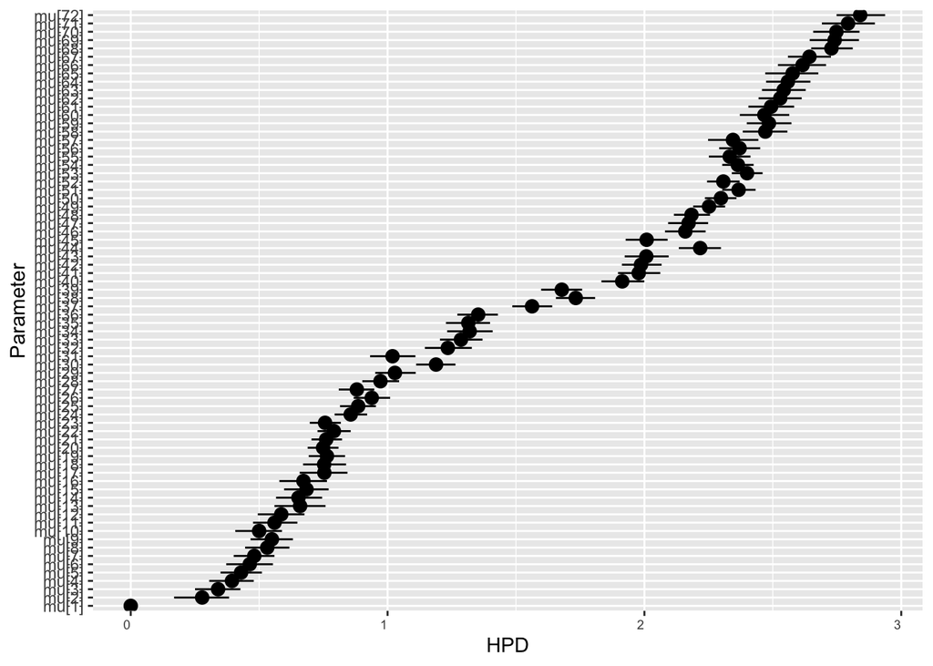

```r
# Convert into ggmcmc object
bayes.mod.fit.gg <- ggs(bayes.mod.fit.mcmc)

ggs_caterpillar(bayes.mod.fit.gg,
                family = "mu",
                thick_ci = c(0.45,0.55),
                sort = FALSE)
```

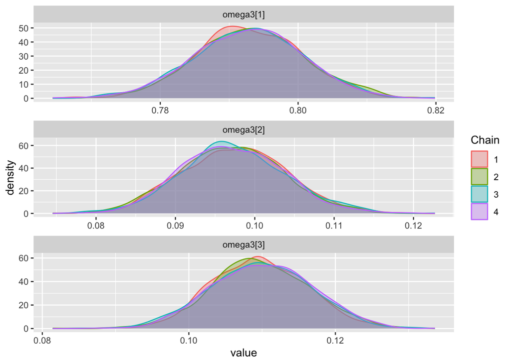

```r
ggs_density(bayes.mod.fit.gg,
            family = "omega3")
```

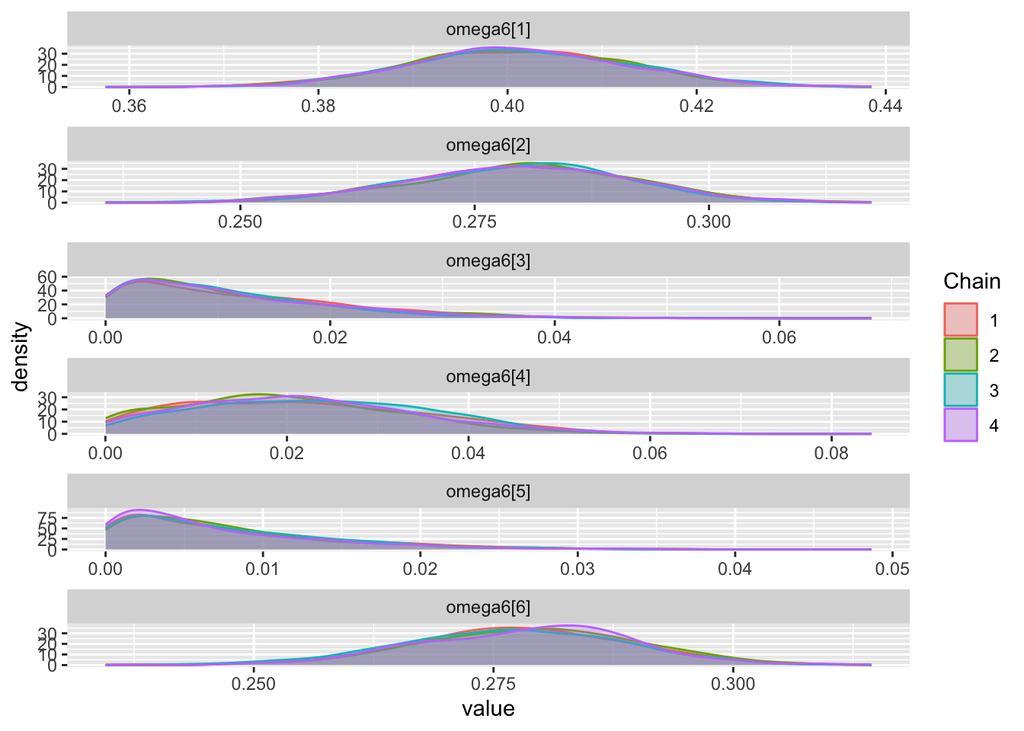

```r
ggs_density(bayes.mod.fit.gg,
            family = "omega6")
```